# MCAC Evaluation

Jeffrey Smith

2018-03-15

# Introduction

This document serves as the evaluation of Alexander Trigo’s Multivariate Chi-Square Anomaly Classification (MCAC) analytic tool. This tool was developed for the purpose of providing a user the ability to quickly and automatically detect cyber intrusion through the identification of outliers and to provide visual insight into the dataset. The developer has provided a workable dataset to be used for test purposes for this analytic. The developer has also created an Rshiny package to be used for the analysis. This evaluation will focus on the shiny application as it is structured on the underlying package functions.

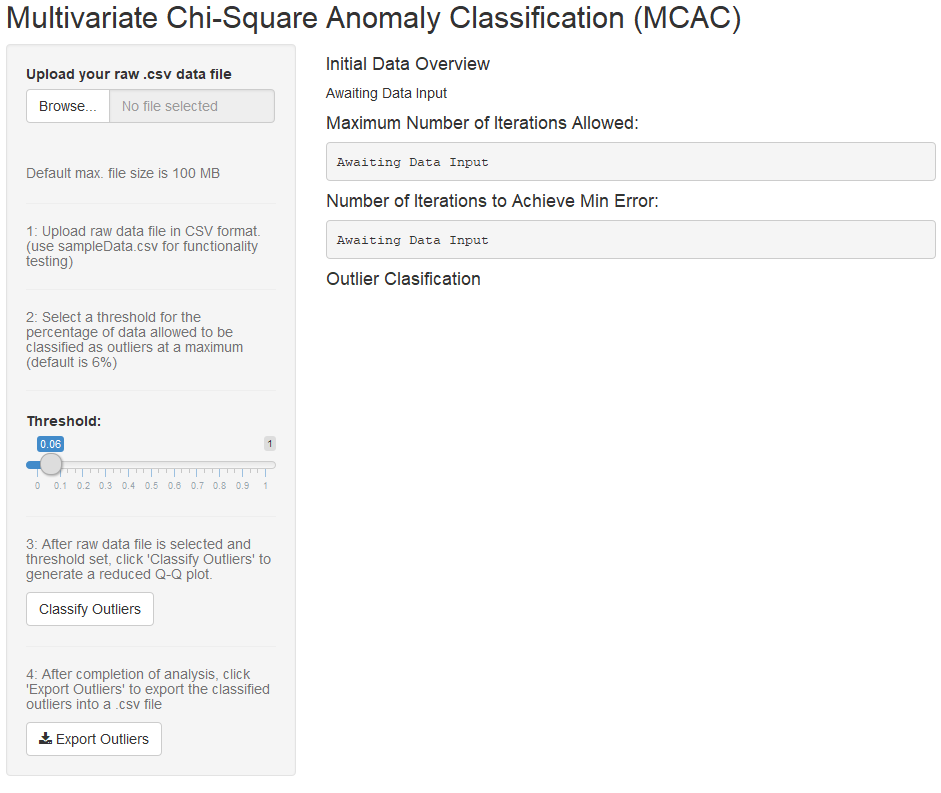

Shiny Application

# Accuracy

The accuracy of the data appears to be without error. The data provided is automatically cleaned with the implementation of the `prepareData` function.

# Ease of USe

This analytic started up correctly with no errors occurring.

# Compilation

Upon entering data into the analytic, the user will be presented with three subheadings that allow for further analysis and insight into the data.

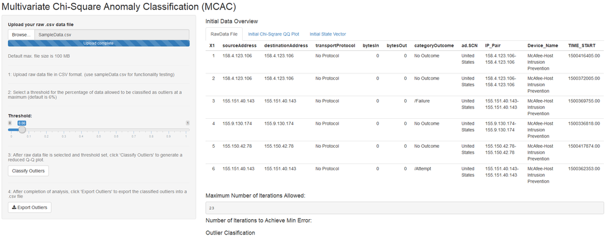

At this point the user has the ability to navigate through three tabs under the “Initial Data Overview” Header. These tabs consist of the “RawData File”, which provides a visual of the data within the file and the “Initial Chi-Square QQ Plot”, which provides a chi-square quantile quantile plot of data points. Lastly the “Initial State Vector” tab. It is not clear what additional information this tab is providing, but it is assumed that users with some background in the subject matter will understand its purpose.

Upon clicking the “Classify Outliers” Action button a reduced Chi-Square plot is generated, without error. Adjusting the “Threshold” slider and clicking the action button will rerun the analysis while adjusting the maximum number of iterations allowed and the number of iterations to achieve minimum error.

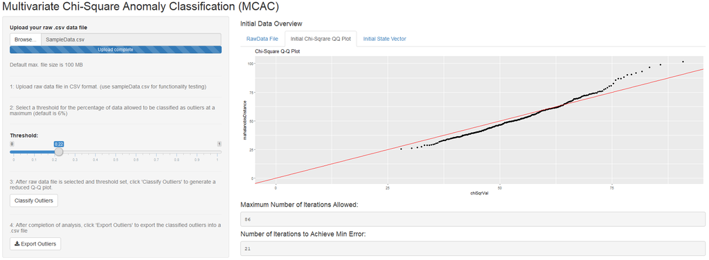

With the completion of the analysis the user is prompted to Export Outliers, which creates a csv file in a local directory. This action button also works as intended.

# Evaluation Grade: 50 (Outstanding)

The elements built into the analytic all function correctly and work as I believed the developer intended. There were quite a few additional functions that were not added to the tool, but the developer acknowledged this fact in the Rmd file.